# Swire Coca-Cola USA (SCCU) - Group Modeling Notebook

## Multi-Dimensional Clustering

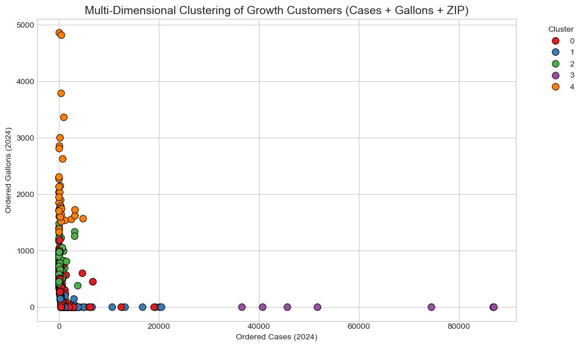

```python
#Multi-Dimensional Clustering (ZIP + Cases + Gallons)
import pandas as pd
import numpy as np
import matplotlib.pyplot as plt
import seaborn as sns
from sklearn.cluster import KMeans
from sklearn.preprocessing import StandardScaler

# Filter growth customers with valid data
transitioned_customers = df[
    (df['THRESHOLD_2023'].str.lower() == 'below') &
    (df['THRESHOLD_2024'].str.lower() == 'above')
]

cluster_df = transitioned_customers[
    ['ZIP_CODE', 'ANNUAL_VOLUME_CASES_2024', 'ANNUAL_VOLUME_GALLON_2024']
].dropna()

#  Clean & transform ZIP (ensure it's numeric)
cluster_df = cluster_df[cluster_df['ZIP_CODE'].apply(lambda x: str(x).isdigit())]
cluster_df['ZIP_CODE'] = cluster_df['ZIP_CODE'].astype(int)

#  Scale the features (KMeans is distance-based)
features = ['ZIP_CODE', 'ANNUAL_VOLUME_CASES_2024', 'ANNUAL_VOLUME_GALLON_2024']
scaler = StandardScaler()
X_scaled = scaler.fit_transform(cluster_df[features])

# Run KMeans clustering
kmeans = KMeans(n_clusters=5, random_state=42)
cluster_df['Cluster'] = kmeans.fit_predict(X_scaled)

# Visualize clusters — 2D projection (Cases vs Gallons colored by cluster)
plt.figure(figsize=(10, 6))
sns.scatterplot(
    data=cluster_df,
    x='ANNUAL_VOLUME_CASES_2024',
    y='ANNUAL_VOLUME_GALLON_2024',
    hue='Cluster',
    palette='Set1',
    s=70,
    edgecolor='black'
)
plt.title("Multi-Dimensional Clustering of Growth Customers (Cases + Gallons + ZIP)", fontsize=14)
plt.xlabel("Ordered Cases (2024)")
plt.ylabel("Ordered Gallons (2024)")
plt.legend(title="Cluster", bbox_to_anchor=(1.05, 1), loc='upper left')
plt.grid(True)
plt.tight_layout()
plt.show()
```

Instead of clustering by a single feature, this approach uses ZIP code + case + gallon volume to create real-world customer segments based on both location and behavior.

## Average Delivery Cost Per Case

```python
import pandas as pd
import numpy as np

# Step 1: Filter valid data where both delivery cost and volume are positive
valid_cost_data = transitioned_customers[
    (transitioned_customers["DELIVERY_COST_2024"] > 0) &
    (transitioned_customers["ANNUAL_VOLUME_CASES_2024"] > 0)
].copy()

# Step 2: Calculate cost per case for each customer
valid_cost_data["Cost_Per_Case"] = valid_cost_data["DELIVERY_COST_2024"] / valid_cost_data["ANNUAL_VOLUME_CASES_2024"]

# Step 3: Take the average of all valid cost-per-case values
cost_per_case = valid_cost_data["Cost_Per_Case"].mean()

# Step 4: Output result
print(f"Actual Average Delivery Cost per Case (2024): ${cost_per_case:.2f}")
```

```
Actual Average Delivery Cost per Case (2024): $40.92
```

## Before Vs After Clustering -Comparing Cost per Delivery

```python
#Compare Cost Per Delivery: Before vs. After Clustering

#  Calculate Average Cost Per Case BEFORE Clustering
# Filter improved customers with valid delivery cost and order volume
improved_customers = transitioned_customers[
    (transitioned_customers["DELIVERY_COST_2024"] > 0) &
    (transitioned_customers["ANNUAL_VOLUME_CASES_2024"] > 0)
].copy()  # use .copy() to avoid SettingWithCopyWarning

# Calculate cost per case for each improved customer
improved_customers["Cost_Per_Case"] = improved_customers["DELIVERY_COST_2024"] / improved_customers["ANNUAL_VOLUME_CASES_2024"]

# Compute the average cost per case before clustering
avg_cost_before = improved_customers["Cost_Per_Case"].mean()
print(f"Actual Average Cost Per Case BEFORE Clustering: ${avg_cost_before:.2f}")

# Calculate Average Cost Per Case AFTER Clustering (Validated)
# Merge the growth_customers (from clustering, Step 14) with actual cost data from improved_customers
merged = growth_customers.merge(
    improved_customers[["ZIP_CODE", "DELIVERY_COST_2024", "ANNUAL_VOLUME_CASES_2024"]],
    on="ZIP_CODE",
    how="left"
).dropna()

# Group by cluster and sum up the delivery cost and total cases
cluster_actuals = merged.groupby("Cluster").agg({
    "DELIVERY_COST_2024": "sum",
    "ANNUAL_VOLUME_CASES_2024": "sum"
}).reset_index()

# Compute average cost per case for each cluster and overall (weighted)
cluster_actuals["Cost_Per_Case"] = cluster_actuals["DELIVERY_COST_2024"] / cluster_actuals["ANNUAL_VOLUME_CASES_2024"]

total_cost = cluster_actuals["DELIVERY_COST_2024"].sum()
total_cases = cluster_actuals["ANNUAL_VOLUME_CASES_2024"].sum()
validated_avg_cost_after = total_cost / total_cases

print(f" Validated Average Cost Per Case AFTER Clustering: ${validated_avg_cost_after:.2f}")

# Calculate estimated savings per case due to clustering
savings = avg_cost_before - validated_avg_cost_after
print(f"Estimated Savings Per Case from Routing Clusters: ${savings:.2f}")

# Optional: Display Cluster-Level Details
print("\nCluster-Level Actuals:")
print(cluster_actuals[['Cluster', 'DELIVERY_COST_2024', 'ANNUAL_VOLUME_CASES_2024', 'Cost_Per_Case']])
```

```
Actual Average Cost Per Case BEFORE Clustering: $40.92
 Validated Average Cost Per Case AFTER Clustering: $2.19
Estimated Savings Per Case from Routing Clusters: $38.73

Cluster-Level Actuals:
   Cluster  DELIVERY_COST_2024  ANNUAL_VOLUME_CASES_2024  Cost_Per_Case
0        0        1.372571e+06              3.311752e+05       4.144548
1        1        2.304221e+06              1.027345e+06       2.242891
2        2        1.220535e+06              3.616110e+05       3.375270
3        3        2.396896e+06              1.007614e+06       2.378786
4        4        3.472352e+06              2.180573e+06       1.592404
```

.total_cost = sum of DELIVERY_COST_2024 across all clustered customers .total_cases = sum of ANNUAL_VOLUME_CASES_2024 across those customers . Avg. Cost per Case = total_cost / total_cases = $2.19. Indicates major efficiency gains from optimizing customer grouping and routing.

## Percentage Cost Savings

```python
# Show Cost Savings as a Percentage

savings_per_case = avg_cost_before - validated_avg_cost_after
percentage_savings = (savings_per_case / avg_cost_before) * 100

# Print full comparison with percentage
print(f"Actual Avg. Cost per Case BEFORE Clustering:  ${avg_cost_before:.2f}")
print(f" Avg. Cost per Case AFTER Clustering:         ${validated_avg_cost_after:.2f}")
print(f" Estimated Savings per Case:                 ${savings_per_case:.2f}")
print(f" Percentage Cost Reduction:                  {percentage_savings:.2f}%")
```

```
Actual Avg. Cost per Case BEFORE Clustering:  $40.92
 Avg. Cost per Case AFTER Clustering:         $2.19
 Estimated Savings per Case:                 $38.73
 Percentage Cost Reduction:                  94.64%
```

After clustering, it dropped to $2.19, saving $38.73 per case — a 94.64% cost reduction driven by more efficient delivery through optimized customer grouping.

## Average Cost per Gallon Before Clustering

```python
# Filter improved customers with valid data( for gallons)
valid_gallon_data = transitioned_customers[
    (transitioned_customers["DELIVERY_COST_2024"] > 0) &
    (transitioned_customers["ANNUAL_VOLUME_GALLON_2024"] > 0)
].copy()

# Calculate cost per gallon
valid_gallon_data["Cost_Per_Gallon"] = valid_gallon_data["DELIVERY_COST_2024"] / valid_gallon_data["ANNUAL_VOLUME_GALLON_2024"]
avg_cost_per_gallon_before = valid_gallon_data["Cost_Per_Gallon"].mean()

print(f"Actual Average Cost per Gallon BEFORE Clustering: ${avg_cost_per_gallon_before:.2f}")
```

```
Actual Average Cost per Gallon BEFORE Clustering: $18.97
```

Calculates actual average delivery cost per gallon using 2024 data from improved customers.This means, on average, it cost $18.97 to deliver each gallon before any clustering or delivery optimization.

## Average cost per Gallon After Clustering

```python
# Merge cost/gallon data into gallon-based clustered customers
gallon_clustered = growth_customers.merge(
    valid_gallon_data[["ZIP_CODE", "DELIVERY_COST_2024", "ANNUAL_VOLUME_GALLON_2024"]],
    on="ZIP_CODE", how="left"
).dropna()

cluster_gallon_costs = gallon_clustered.groupby("Cluster").agg({
    "DELIVERY_COST_2024": "sum",
    "ANNUAL_VOLUME_GALLON_2024": "sum"
}).reset_index()

cluster_gallon_costs["Cost_Per_Gallon"] = cluster_gallon_costs["DELIVERY_COST_2024"] / cluster_gallon_costs["ANNUAL_VOLUME_GALLON_2024"]

# Weighted average (after clustering)
total_cost_gallons = cluster_gallon_costs["DELIVERY_COST_2024"].sum()
total_gallons = cluster_gallon_costs["ANNUAL_VOLUME_GALLON_2024"].sum()
avg_cost_per_gallon_after = total_cost_gallons / total_gallons

print(f"Avg. Cost per Gallon AFTER Clustering: ${avg_cost_per_gallon_after:.2f}")

# Calculate savings
gallon_savings = avg_cost_per_gallon_before - avg_cost_per_gallon_after
percent_gallon_savings = (gallon_savings / avg_cost_per_gallon_before) * 100

print(f"Savings per Gallon: ${gallon_savings:.2f}")
print(f"Percentage Savings from Clustering (Gallons): {percent_gallon_savings:.2f}%")
```

```
Avg. Cost per Gallon AFTER Clustering: $3.61
Savings per Gallon: $15.36
Percentage Savings from Clustering (Gallons): 80.95%
```

Avg. Cost per Gallon Before Clustering: $18.97. After Clustering: $3.61, Savings per Gallon: $15.36 (81% reduction).Indicates significant efficiency gains in liquid deliveries through optimized routing and grouping.

## Visuals for Average Cost per Case Before vs After Clustering

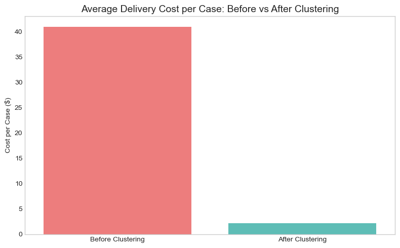

```python
# Visualize Average Cost Per Case Before vs After Clustering

import matplotlib.pyplot as plt
import seaborn as sns

# Bar chart: before vs after clustering
plt.figure(figsize=(8, 5))
sns.barplot(
    x=["Before Clustering", "After Clustering"],
    y=[avg_cost_before, validated_avg_cost_after],
    palette=["#FF6B6B", "#4ECDC4"]
)
plt.title("Average Delivery Cost per Case: Before vs After Clustering", fontsize=14)
plt.ylabel("Cost per Case ($)")
plt.grid(axis="y")
plt.tight_layout()
plt.show()

# Robustness Check — Distribution of Cost per Case

# Before clustering
before_dist = improved_customers[["ZIP_CODE", "Cost_Per_Case"]].copy()
before_dist["Scenario"] = "Before Clustering"

# After clustering
after_dist = merged[["ZIP_CODE", "DELIVERY_COST_2024", "ANNUAL_VOLUME_CASES_2024"]].copy()
after_dist["Cost_Per_Case"] = after_dist["DELIVERY_COST_2024"] / after_dist["ANNUAL_VOLUME_CASES_2024"]
after_dist["Scenario"] = "After Clustering"

# Combine for distribution comparison
distribution_df = pd.concat([
    before_dist[["ZIP_CODE", "Cost_Per_Case", "Scenario"]],
    after_dist[["ZIP_CODE", "Cost_Per_Case", "Scenario"]]
])

# Remove extreme outliers to keep boxplot readable
distribution_df = distribution_df[distribution_df["Cost_Per_Case"] < 150]
```

## Visuals for cost per Gallon Before vs After Clustering

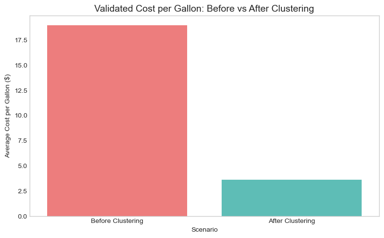

```python
# Ensure variables are consistent and re-run calculation to double-check
# Filter improved customers with valid delivery cost and gallon volume
valid_gallon_data = transitioned_customers[
    (transitioned_customers["DELIVERY_COST_2024"] > 0) &
    (transitioned_customers["ANNUAL_VOLUME_GALLON_2024"] > 0)
].copy()

# Calculate cost per gallon before clustering
valid_gallon_data["Cost_Per_Gallon"] = valid_gallon_data["DELIVERY_COST_2024"] / valid_gallon_data["ANNUAL_VOLUME_GALLON_2024"]
avg_cost_per_gallon_before = valid_gallon_data["Cost_Per_Gallon"].mean()

# Merge cluster assignments into valid_gallon_data
gallon_clustered = growth_customers.merge(
    valid_gallon_data[["ZIP_CODE", "DELIVERY_COST_2024", "ANNUAL_VOLUME_GALLON_2024"]],
    on="ZIP_CODE", how="left"
).dropna()

# Group by cluster to calculate cost per gallon after clustering
cluster_gallon_costs = gallon_clustered.groupby("Cluster").agg({
    "DELIVERY_COST_2024": "sum",
    "ANNUAL_VOLUME_GALLON_2024": "sum"
}).reset_index()

# Calculate weighted average after clustering
total_cost_gallons = cluster_gallon_costs["DELIVERY_COST_2024"].sum()
total_gallons = cluster_gallon_costs["ANNUAL_VOLUME_GALLON_2024"].sum()
avg_cost_per_gallon_after = total_cost_gallons / total_gallons

# Bar plot: Before vs After clustering
import matplotlib.pyplot as plt
import seaborn as sns

gallon_cost_comparison = pd.DataFrame({
    "Scenario": ["Before Clustering", "After Clustering"],
    "Cost_Per_Gallon": [avg_cost_per_gallon_before, avg_cost_per_gallon_after]
})

plt.figure(figsize=(8, 5))
sns.barplot(data=gallon_cost_comparison, x="Scenario", y="Cost_Per_Gallon", palette=["#FF6B6B", "#4ECDC4"])
plt.title("Validated Cost per Gallon: Before vs After Clustering", fontsize=14)
plt.ylabel("Average Cost per Gallon ($)")
plt.grid(axis="y")
plt.tight_layout()
plt.show()
```

### Annual Delivery Cost Statistics

```python
# Read the CSV file
final_df = pd.read_csv(file_path)

# Min and Max for 2023 and 2024
min_cost_2023 = float(final_df['DELIVERY_COST_2023'].min())  # Convert to float
max_cost_2023 = float(final_df['DELIVERY_COST_2023'].max())

min_cost_2024 = float(final_df['DELIVERY_COST_2024'].min())
max_cost_2024 = float(final_df['DELIVERY_COST_2024'].max())

# Average delivery cost per customer
avg_cost_2023 = float(final_df['DELIVERY_COST_2023'].mean())
avg_cost_2024 = float(final_df['DELIVERY_COST_2024'].mean())

# # Display results
print("Delivery Cost Summary:")
print(f"2023 → Min: ${min_cost_2023:.2f}, Max: ${max_cost_2023:.2f}, Avg: ${avg_cost_2023:.2f}")
print(f"2024 → Min: ${min_cost_2024:.2f}, Max: ${max_cost_2024:.2f}, Avg: ${avg_cost_2024:.2f}")
```

```
Delivery Cost Summary:
2023 → Min: $0.00, Max: $67412.32, Avg: $1117.69
2024 → Min: $0.00, Max: $94393.82, Avg: $1173.53
```

The minimum delivery cost per customer in both 2023 and 2024 was USD 0, indicating some customers incurred no delivery charges. The maximum delivery cost increased from USD 67,412.32 in 2023 to USD 94,393.82 in 2024, reflecting a USD 26,981.50 rise. On average, customers experienced a modest increase in delivery cost, from 1,117.69 in 2023 to 1173.53 USD in 2024, resulting in an average difference of about $56 in the costs between 2023 and 2024.

### Modelling: Predicting potential growth-ready customers

#### Prepare the Data

```python
# Get the Target Variable and variables to consider to model

# Create T.V1: growth-ready
final_df['GROWTH_READY'] = ((final_df['THRESHOLD_2023'] == 'below') & (final_df['THRESHOLD_2024'] == 'above')).astype(int)

# Step 1: Strip whitespace from column names
final_df.columns = final_df.columns.str.strip()

# Step 2: Drop unwanted columns
drop_cols = ['Unnamed: 0','CUSTOMER_NUMBER', 'FIRST_TRANSACTION_DATE', 'LAST_TRANSACTION_DATE',
             'FIRST_DELIVERY_DATE','ON_BOARDING_DATE','THRESHOLD_2023', 'THRESHOLD_2024',
             'ANNUAL_VOLUME_CASES_2024', 'ANNUAL_VOLUME_GALLON_2024',
             'ANNUAL_VOLUME_2024','AVG_ORDER_VOLUME_2024','PRIMARY_GROUP_NUMBER',
             'CHANGED_VOLUME', 'PERCENT_CHANGE','DELIVERY_COST_2024_CASE','DELIVERY_COST_2024_CASES',
             'DELIVERY_COST_2024_GALLON','DELIVERY_COST_2024', 'TRANS_COUNT','TRANS_DAYS',
             'TRANS_COUNT_2024']

df_model = final_df.drop(columns=drop_cols, errors='ignore')

# Step 3: Drop all columns that start with 'Vol Range'
vol_range_cols = [col for col in df_model.columns if col.strip().startswith('Vol Range_')]
df_model = df_model.drop(columns=vol_range_cols, errors='ignore')


# Step 4: One-hot encode categorical variables
df_model = pd.get_dummies(df_model, drop_first=True)

# Step 5: Separate features and target
X = df_model.drop(columns='GROWTH_READY')
y = df_model['GROWTH_READY']

# Step 6: Check balance of the target
print(y.value_counts(normalize=True))
```

```
GROWTH_READY
0    0.958771
1    0.041229
Name: proportion, dtype: float64
```

> About 4% of the customers from the historical data are growth-ready and 96% of them fall under any one of these categories - low potential, high potential, or declining growth.